# Analysis of Agilent single-channel microarrays

**Authors**: *Momeneh (Sepideh) Foroutan* and *Ramyar Molania*

In this document, we explain how we can analyse microarray single-channel data from the Agilent technology. we start by downloading the data from GEO using GEOquery package. Then we normalise the data, and perform differential expression analysis using limma package.

The GEO accession number of the data that we use is “GSE28569”.

First, we should make sure that we have all the required libraries for our analysis. most of these packages are available through [Bioconductor](https://www.bioconductor.org). Here, we show you how to make another script that has all required packages for microarray analysis, and so instead of installing and loading them here, we just need to “source” that script before doing anything else. We name that script “RequiredPackagesMicroarryAnalysis.R”.

```r
pkgPath<- "/Users/Sepideh/Documents/Scripts/FreqUsedScripts/"
source(paste0(pkgPath, "RequiredPackagesMicroarrayAnanlysis.R"))

# source("http://bioconductor.org/biocLite.R")
# biocLite(c("GEOquery", "limma", "dplyr", "ggplot2", "edgeR", "RSubread", "affy", "matrixStats"))
# #add statmod and GO.db and org.Hs.eg.db package
# library(limma)
```

## Download and read the data

Download the raw data and sample information.

```r
## processed data:
gse <- getGEO("GSE28569", GSEMatrix = TRUE)
save(gse, file="gse.RData")
## raw data:
GEOrawPath<- getGEOSuppFiles("GSE28569")

## untar the raw data:
untar("./GSE28569/GSE28569_RAW.tar")

## sometimes sample info can be obtained through this function:
# sampleInfo <- getGSEDataTables("GSE28569")
```

We are only interested in four samples: two controls and two TGFb treated samples. So in this chunck we read the data related to only these samples. Note that it generates an object of EListRaw class which is designed for one-colour agilent data.

The foreground and background signals for each spot can be estimated using the mean or the median of the foreground and background pixels. Background signal is ususally estimated by median signal, whereas we can change the foreground signal estimation method by setting the source parameter: “agilent” and “agilent.median” will calculate the median signal while “agilent.mean” will calculate the mean signal. In the below code, source= “agilent” is the default setting which is based on median signal for foreground.

In addition to the intensity columns, the agilent file contains some annotation columns. The read.maimages() function reads the following annotation columns (if they exist): Row, Col, Start, Sequence, SwissProt, GenBank, Primate, GenPept, ProbeUID, ControlType, ProbeName, GeneName, SystematicName, Description. Here, we explicitly select the annotation columns that we care about.

```r
load("gse.RData")
gse[[1]]
```

```
ExpressionSet (storageMode: lockedEnvironment)
assayData: 41093 features, 8 samples
  element names: exprs
protocolData: none
phenoData
  sampleNames: GSM707310 GSM707311 ... GSM707317 (8 total)
  varLabels: title geo_accession ... data_row_count (43 total)
  varMetadata: labelDescription
featureData
  featureNames: (+)E1A_r60_1 (+)E1A_r60_3 ... RC9 (41093 total)
  fvarLabels: ID SPOT_ID ... SEQUENCE (17 total)
  fvarMetadata: Column Description labelDescription
experimentData: use 'experimentData(object)'
Annotation: GPL6480
```

```r
## look at the processed data:
head(exprs(gse[[1]]))
```

```
                GSM707310 GSM707311 GSM707312 GSM707313 GSM707314 GSM707315
(+)E1A_r60_1    17.246819 18.380106 17.719396 17.615262 17.886757 17.809304
(+)E1A_r60_3     5.768184  5.815907  5.898066  5.865093  5.563929  5.642131
(+)E1A_r60_a104  5.584962  5.856322  5.757204  5.782631  5.598695  5.650901
(+)E1A_r60_a107  5.906890  6.521382  6.149874  6.052720  6.039267  6.142560
(+)E1A_r60_a135  7.709084  9.002132  8.112770  7.991320  8.288526  8.244581
(+)E1A_r60_a20   9.146569 10.490900  9.536814  9.493371  9.843455  9.744010
                GSM707316 GSM707317
(+)E1A_r60_1    17.504517 17.766633
(+)E1A_r60_3     5.562625  5.727557
(+)E1A_r60_a104  5.605438  5.693610
(+)E1A_r60_a107  5.968945  6.108647
(+)E1A_r60_a135  8.009359  8.186986
(+)E1A_r60_a20   9.486221  9.656641
```

```r
## look at the phenotypic data:
dim(pData(gse[[1]]))
```

```
[1]  8 43
```

```r
head(pData(gse[[1]]))
```

|  | title | geo_accession | status | submission_date | last_update_date | type | channel_count | source_name_ch1 | organism_ch1 | characteristics_ch1 | characteristics_ch1.1 | characteristics_ch1.2 | characteristics_ch1.3 | characteristics_ch1.4 | treatment_protocol_ch1 | treatment_protocol_ch1.1 | treatment_protocol_ch1.2 | growth_protocol_ch1 | growth_protocol_ch1.1 | molecule_ch1 | extract_protocol_ch1 | label_ch1 | label_protocol_ch1 | taxid_ch1 | hyb_protocol | scan_protocol | description | description.1 | data_processing | … |
| --- | --- | --- | --- | --- | --- | --- | --- | --- | --- | --- | --- | --- | --- | --- | --- | --- | --- | --- | --- | --- | --- | --- | --- | --- | --- | --- | --- | --- | --- | --- |
| GSM707310 | WT-1, control human MCF10A cells | GSM707310 | Public on May 07 2012 | Apr 12 2011 | May 07 2012 | RNA | 1 | MCF10A cells, control | Homo sapiens | gender: female | cell line: MCF10A | cell type: breast mammary gland epithelial cells | genotype: parental |  | MCF10A cells were grown as described for 3 days in the absence (WT) or presence of 4 ng/ml recombinant TGFβ1 (TGF). | Stable silencing of gene expression in MCF10A cells was accomplished by transduction with lentiviruses pLKO1 (SHVRCS-TRCN000003796, Sigma-Mission), followed by selection with puromycin (96). Specifici… | -1' and '-2' correspond to two successive cell passages. | MCF-10A is a spontaneously immortalized, but nontransformed human mammary epithelial cell line derived from the breast tissue of a 36-year-old patient with fibrocystic changes. | MCF-10A cells are grown on standard tissue culture plastic in a 5% CO2 humidified incubator at 37°C. The growth medium contains several additives and is composed of DMEM/F12 supplemented with 5% donor… | total RNA | Total RNA extraction was performed using the Absolutely RNA Miniprep kit (Agilent). | Cy3 | Five hundred ng of total RNA was converted into labeled cRNA with nucleotides coupled to fluorescent dye Cy3 using the Low RNA Input Linear Amplification Kit (Agilent Technologies, Palo Alto, CA) foll… | 9606 | According to the Cogenics/Agilent protocol. | Microarrays were scanned and raw data were extracted from the scanned images using Feature Extraction version 9.5. | WT-1 | Parental MCF10A cells grown for 3 days (passage 15). | Raw data were normalized with the vsn method (R package limma, Smyth and Speed, 2003) and differential analysis was performed with the samr package (Tusher, 2001). Regulated genes were selected based … | … |
| GSM707311 | TGF-1, +TGFbeta1, human MCF10A cells | GSM707311 | Public on May 07 2012 | Apr 12 2011 | May 07 2012 | RNA | 1 | MCF10A cells, TGFbeta1 | Homo sapiens | gender: female | cell line: MCF10A | cell type: breast mammary gland epithelial cells | genotype: parental | treatment: TGFβ1 | MCF10A cells were grown as described for 3 days in the absence (WT) or presence of 4 ng/ml recombinant TGFβ1 (TGF). | Stable silencing of gene expression in MCF10A cells was accomplished by transduction with lentiviruses pLKO1 (SHVRCS-TRCN000003796, Sigma-Mission), followed by selection with puromycin (96). Specifici… | -1' and '-2' correspond to two successive cell passages. | MCF-10A is a spontaneously immortalized, but nontransformed human mammary epithelial cell line derived from the breast tissue of a 36-year-old patient with fibrocystic changes. | MCF-10A cells are grown on standard tissue culture plastic in a 5% CO2 humidified incubator at 37°C. The growth medium contains several additives and is composed of DMEM/F12 supplemented with 5% donor… | total RNA | Total RNA extraction was performed using the Absolutely RNA Miniprep kit (Agilent). | Cy3 | Five hundred ng of total RNA was converted into labeled cRNA with nucleotides coupled to fluorescent dye Cy3 using the Low RNA Input Linear Amplification Kit (Agilent Technologies, Palo Alto, CA) foll… | 9606 | According to the Cogenics/Agilent protocol. | Microarrays were scanned and raw data were extracted from the scanned images using Feature Extraction version 9.5. | TGF-1 | Parental MCF10A cells grown for 3 days (passage 15) in the presence of 4 ng/ml TGFβ1. | Raw data were normalized with the vsn method (R package limma, Smyth and Speed, 2003) and differential analysis was performed with the samr package (Tusher, 2001). Regulated genes were selected based … | … |
| GSM707312 | 96-1, shRNA, human MCF10A cells | GSM707312 | Public on May 07 2012 | Apr 12 2011 | May 07 2012 | RNA | 1 | MCF10A cells, CK2beta depletion | Homo sapiens | gender: female | cell line: MCF10A | cell type: breast mammary gland epithelial cells | genotype: stable CK2β-knockdown |  | MCF10A cells were grown as described for 3 days in the absence (WT) or presence of 4 ng/ml recombinant TGFβ1 (TGF). | Stable silencing of gene expression in MCF10A cells was accomplished by transduction with lentiviruses pLKO1 (SHVRCS-TRCN000003796, Sigma-Mission), followed by selection with puromycin (96). Specifici… | -1' and '-2' correspond to two successive cell passages. | MCF-10A is a spontaneously immortalized, but nontransformed human mammary epithelial cell line derived from the breast tissue of a 36-year-old patient with fibrocystic changes. | MCF-10A cells are grown on standard tissue culture plastic in a 5% CO2 humidified incubator at 37°C. The growth medium contains several additives and is composed of DMEM/F12 supplemented with 5% donor… | total RNA | Total RNA extraction was performed using the Absolutely RNA Miniprep kit (Agilent). | Cy3 | Five hundred ng of total RNA was converted into labeled cRNA with nucleotides coupled to fluorescent dye Cy3 using the Low RNA Input Linear Amplification Kit (Agilent Technologies, Palo Alto, CA) foll… | 9606 | According to the Cogenics/Agilent protocol. | Microarrays were scanned and raw data were extracted from the scanned images using Feature Extraction version 9.5. | 96-1 | Stable CK2β-knockdown MCF10A cells grown for 3 days (passage 15). | Raw data were normalized with the vsn method (R package limma, Smyth and Speed, 2003) and differential analysis was performed with the samr package (Tusher, 2001). Regulated genes were selected based … | … |
| GSM707313 | F2-1, +rescue, human MCF10A cells | GSM707313 | Public on May 07 2012 | Apr 12 2011 | May 07 2012 | RNA | 1 | MCF10A cells, CK2beta depletion and rescue | Homo sapiens | gender: female | cell line: MCF10A | cell type: breast mammary gland epithelial cells | genotype: stable CK2β-knockdown | treatment: rescued with chicken CK2β | MCF10A cells were grown as described for 3 days in the absence (WT) or presence of 4 ng/ml recombinant TGFβ1 (TGF). | Stable silencing of gene expression in MCF10A cells was accomplished by transduction with lentiviruses pLKO1 (SHVRCS-TRCN000003796, Sigma-Mission), followed by selection with puromycin (96). Specifici… | -1' and '-2' correspond to two successive cell passages. | MCF-10A is a spontaneously immortalized, but nontransformed human mammary epithelial cell line derived from the breast tissue of a 36-year-old patient with fibrocystic changes. | MCF-10A cells are grown on standard tissue culture plastic in a 5% CO2 humidified incubator at 37°C. The growth medium contains several additives and is composed of DMEM/F12 supplemented with 5% donor… | total RNA | Total RNA extraction was performed using the Absolutely RNA Miniprep kit (Agilent). | Cy3 | Five hundred ng of total RNA was converted into labeled cRNA with nucleotides coupled to fluorescent dye Cy3 using the Low RNA Input Linear Amplification Kit (Agilent Technologies, Palo Alto, CA) foll… | 9606 | According to the Cogenics/Agilent protocol. | Microarrays were scanned and raw data were extracted from the scanned images using Feature Extraction version 9.5. | F2-1 | Stable CK2β-knockdown MCF10A cells rescued with chicken CK2β insensitive to shRNA, grown for 3 days (passage 15). | Raw data were normalized with the vsn method (R package limma, Smyth and Speed, 2003) and differential analysis was performed with the samr package (Tusher, 2001). Regulated genes were selected based … | … |
| GSM707314 | WT-2, control human MCF10A cells | GSM707314 | Public on May 07 2012 | Apr 12 2011 | May 07 2012 | RNA | 1 | MCF10A cells, control | Homo sapiens | gender: female | cell line: MCF10A | cell type: breast mammary gland epithelial cells | genotype: parental |  | MCF10A cells were grown as described for 3 days in the absence (WT) or presence of 4 ng/ml recombinant TGFβ1 (TGF). | Stable silencing of gene expression in MCF10A cells was accomplished by transduction with lentiviruses pLKO1 (SHVRCS-TRCN000003796, Sigma-Mission), followed by selection with puromycin (96). Specifici… | -1' and '-2' correspond to two successive cell passages. | MCF-10A is a spontaneously immortalized, but nontransformed human mammary epithelial cell line derived from the breast tissue of a 36-year-old patient with fibrocystic changes. | MCF-10A cells are grown on standard tissue culture plastic in a 5% CO2 humidified incubator at 37°C. The growth medium contains several additives and is composed of DMEM/F12 supplemented with 5% donor… | total RNA | Total RNA extraction was performed using the Absolutely RNA Miniprep kit (Agilent). | Cy3 | Five hundred ng of total RNA was converted into labeled cRNA with nucleotides coupled to fluorescent dye Cy3 using the Low RNA Input Linear Amplification Kit (Agilent Technologies, Palo Alto, CA) foll… | 9606 | According to the Cogenics/Agilent protocol. | Microarrays were scanned and raw data were extracted from the scanned images using Feature Extraction version 9.5. | WT-2 | Parental MCF10A cells grown for 3 days (passage 16). | Raw data were normalized with the vsn method (R package limma, Smyth and Speed, 2003) and differential analysis was performed with the samr package (Tusher, 2001). Regulated genes were selected based … | … |
| GSM707315 | TGF-2, +TGFbeta1, human MCF10A cells | GSM707315 | Public on May 07 2012 | Apr 12 2011 | May 07 2012 | RNA | 1 | MCF10A cells, TGFbeta1 | Homo sapiens | gender: female | cell line: MCF10A | cell type: breast mammary gland epithelial cells | genotype: parental | treatment: TGFβ1 | MCF10A cells were grown as described for 3 days in the absence (WT) or presence of 4 ng/ml recombinant TGFβ1 (TGF). | Stable silencing of gene expression in MCF10A cells was accomplished by transduction with lentiviruses pLKO1 (SHVRCS-TRCN000003796, Sigma-Mission), followed by selection with puromycin (96). Specifici… | -1' and '-2' correspond to two successive cell passages. | MCF-10A is a spontaneously immortalized, but nontransformed human mammary epithelial cell line derived from the breast tissue of a 36-year-old patient with fibrocystic changes. | MCF-10A cells are grown on standard tissue culture plastic in a 5% CO2 humidified incubator at 37°C. The growth medium contains several additives and is composed of DMEM/F12 supplemented with 5% donor… | total RNA | Total RNA extraction was performed using the Absolutely RNA Miniprep kit (Agilent). | Cy3 | Five hundred ng of total RNA was converted into labeled cRNA with nucleotides coupled to fluorescent dye Cy3 using the Low RNA Input Linear Amplification Kit (Agilent Technologies, Palo Alto, CA) foll… | 9606 | According to the Cogenics/Agilent protocol. | Microarrays were scanned and raw data were extracted from the scanned images using Feature Extraction version 9.5. | TGF-2 | Parental MCF10A cells grown for 3 days (passage 16) in the presence of 4 ng/ml TGFβ1. | Raw data were normalized with the vsn method (R package limma, Smyth and Speed, 2003) and differential analysis was performed with the samr package (Tusher, 2001). Regulated genes were selected based … | … |

```r
sampleInfo<- pData(gse[[1]])
sampleInfo<- sampleInfo[, c("source_name_ch1", "description")]
## we only want to use TGFb treated and not-treated samples:
pheno<- sampleInfo [ grepl("TGF", sampleInfo$description) |
                       grepl("WT", sampleInfo$description) , ]
pheno$group<-  c("Control", "TGFb", "Control", "TGFb")
phenoFiles<- paste0(row.names(pheno), ".txt.gz")
data<- read.maimages(files = phenoFiles, source="agilent", green.only=TRUE,
                     annotation=c("ProbeUID", "ControlType", "ProbeName",
                                  "GeneName","SystematicName", "accessions"))
```

```
Read GSM707310.txt.gz
Read GSM707311.txt.gz
Read GSM707314.txt.gz
Read GSM707315.txt.gz
```

Note that the raw intensities are stored in the E component of the data object. Let’s have a look at the head of the raw data.

```r
head(data$E)
```

```
     GSM707310.txt GSM707311.txt GSM707314.txt GSM707315.txt
[1,]       64004.9       97674.0       95849.9       98223.8
[2,]          43.0          38.0          37.0          36.5
[3,]          39.0          34.0          34.0          34.0
[4,]          42.0          35.0          35.0          35.5
[5,]          41.5          37.0          36.0          34.0
[6,]          40.5          34.5          34.0          35.0
```

We need to add gene symbols and Entrez IDs to probes.

```r
geneInfo<- alias2SymbolUsingNCBI(data$gene$GeneName,"Homo_sapiens.gene_info")
data$genes <- data.frame(data$genes, geneInfo)
data$targets<- data.frame(data$targets, pheno)
```

## Data normalisation

Now we perform background correction and normalise the data. Note that the default normalisation method for Agilent data in limma is “Saddle”, however, we use “MLE” qhich is similar to Saddle.

```r
dataBGcor <-backgroundCorrect(data, method= "normexp", normexp.method="mle")
```

```
Array 1 corrected
Array 2 corrected
Array 3 corrected
Array 4 corrected
```

```r
dataNorm<-normalizeBetweenArrays(dataBGcor, method="quantile")
```

```r
head(dataNorm$E)
```

```
     GSM707310.txt GSM707311.txt GSM707314.txt GSM707315.txt
[1,]     15.953474     16.667898     16.478719     16.638765
[2,]      4.278344      4.346219      4.202506      4.091161
[3,]      4.080541      3.827203      3.900918      3.815097
[4,]      4.231595      4.048576      4.015919      4.091161
[5,]      4.212268      4.250419      4.202506      3.815097
[6,]      4.152971      4.015919      3.900918      4.027024
```

We can save the expressionSet data in R using the save() function.

```r
save(dataNorm, file="agilent_normalisedData.RData")
```

## Quality control

Let’s look at some plots for the raw data to check the quality of the data.

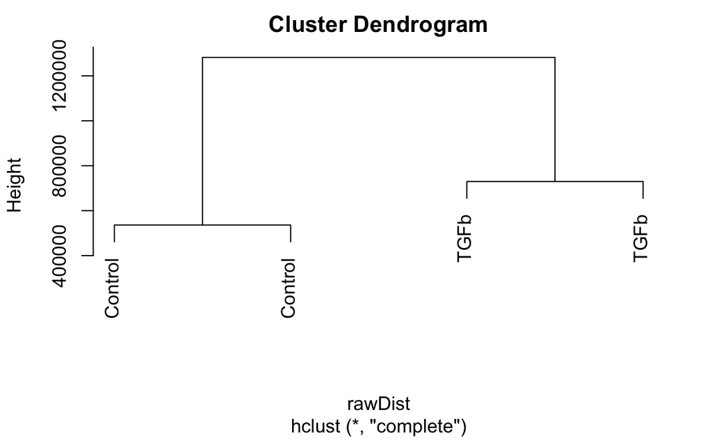

```r
##-------- check to see if the data are clustered as expected:
rawDist<- dist(t(data$E))
plot(hclust(rawDist), labels = data$targets$group)
##-------- non-metrix multi-dimensional scaling:
par(mar=c(5,5,3,2))
```

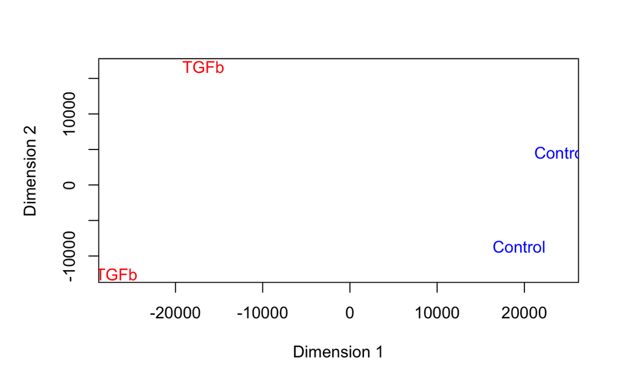

```r
plotMDS(data$E, labels = data$targets$group,
        xlab="Dimension 1", ylab="Dimension 2",
        col= c("blue", "red", "blue", "red"))
```

Then we look at the normalised data:

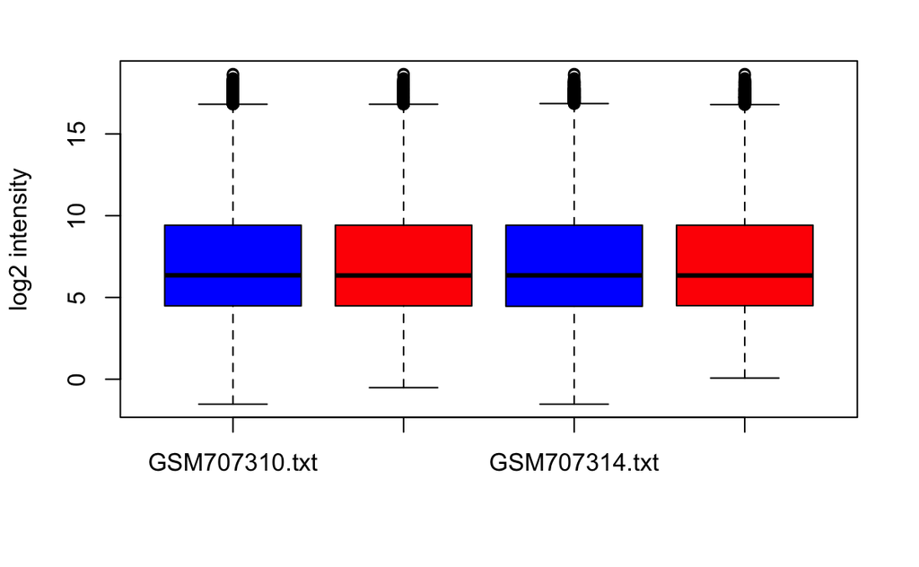

```r
boxplot(dataNorm$E, col= c("blue", "red", "blue", "red"),
        ylab="log2 intensity")
```

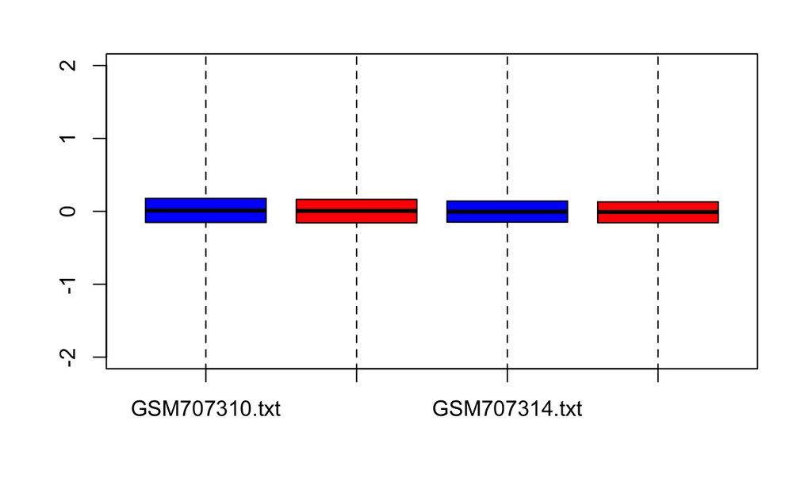

```r
boxplot(dataNorm$E- rowMedians(dataNorm$E),
        col= c("blue", "red", "blue", "red"),
        range=0, ylim=c(-2, 2))
```

## Filtering

If we want to filter the data for control probes or low-count probes, we should do this now.

```r
## look at the table of probe types: -1 for negative controls, 0 for regular probes
table(dataNorm$genes$ControlType)
```

```
   -1     0     1
  153 43376  1486
```

```r
## calculate the %95 of the intensity of negative control genes
neg95 <- apply(dataNorm$E[dataNorm$genes$ControlType==-1,],2,function(x) quantile(x,p=0.95))
## We keep probes that are at least 10% brighter than the negative controls on at least two arrays (because there are two replicates)
cutoff <- matrix(1.1*neg95,nrow(dataNorm),ncol(dataNorm),byrow=TRUE)
isexpr <- rowSums(dataNorm$E > cutoff) >= 2
table(isexpr)
```

```
isexpr
FALSE  TRUE
12892 32123
```

```r
## only get the regular probes that have high expression:
dataNormFilt<- dataNorm[dataNorm$genes$ControlType==0 & isexpr,]
```

## DE analysis

We then find genes differentially expressed in TGFb-treated samples vs. non-treated samples.

```r
## define a group vector contatining info for the four samples (in the same order as the arrays in the expression matrix)
group<- dataNormFilt$targets$group
## we can also change the refrence level:
## group <- relevel(group, ref="...")
design <- model.matrix( ~ group)
fit <- lmFit (dataNormFilt, design)
fit <- eBayes(fit, trend=TRUE, robust = T)
```

```
One very small variance detected, has been offset away from zero
```

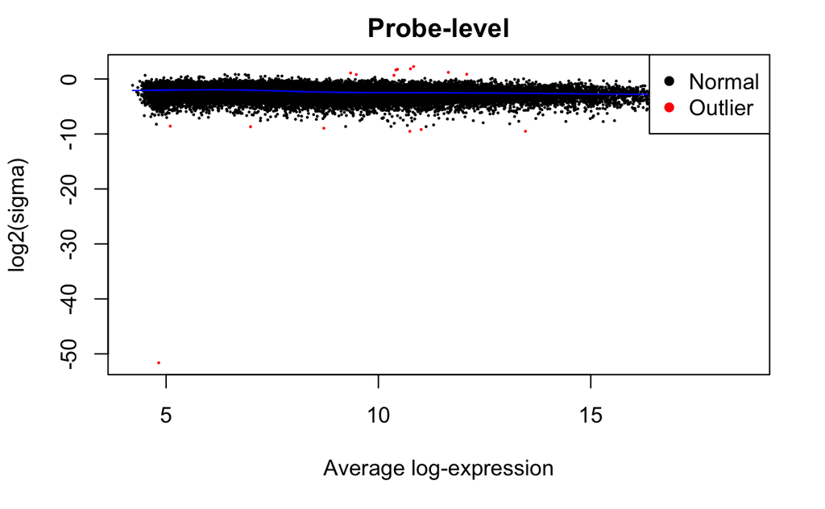

```r
## log residual standard deviation versus average log expression
plotSA(fit, main="Probe-level")
```

```r
summary(decideTests(fit[,-1]))
```

```
   groupTGFb
-1      2389
0      26977
1       2392
```

Because There are more than one probe mapped to the same gene, we can summarise probe-level expression to the gene-level expression. Basically, we calculate the mean of the probes for a specific gene. Then again, we fit the model to obtain the test statistics at the level of gene.

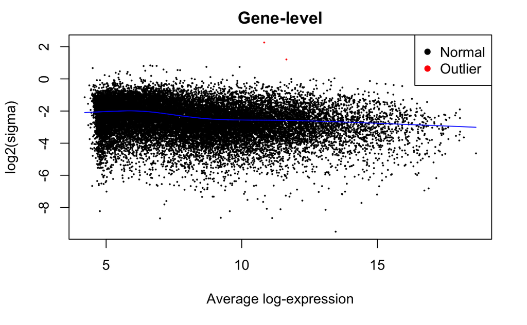

```r
dataGene <- avereps(dataNormFilt, ID=dataNormFilt$genes[,"GeneName"])
fitg <- lmFit(dataGene,design)
fitg <- eBayes(fitg,trend=TRUE, robust = T)
plotSA(fitg, main="Gene-level")
```

```r
summary(decideTests(fitg[,-1]))
```

```
   groupTGFb
-1      1837
0      18771
1       1674
```

Let’s look at the top differentially expressed genes.

```r
toptable(fitg, coef=2)
```

|  | logFC | t | P.Value | adj.P.Val | B |
| --- | --- | --- | --- | --- | --- |
| ANKRD38 | 7.039346 | 38.94277 | 6.715297e-09 | 6.656672e-05 | 10.508853 |
| SCG5 | 6.762619 | 36.37555 | 1.040764e-08 | 6.656672e-05 | 10.242778 |
| POSTN | 6.382930 | 36.07639 | 1.097457e-08 | 6.656672e-05 | 10.209410 |
| CMKOR1 | 6.617566 | 35.60128 | 1.194986e-08 | 6.656672e-05 | 10.155328 |
| ALOX5AP | 6.074203 | 34.28234 | 1.522764e-08 | 6.786044e-05 | 9.997860 |
| CAMK2B | -6.018141 | -30.04291 | 3.551434e-08 | 1.125980e-04 | 9.407864 |
| TAGLN | 5.896183 | 29.34879 | 4.125434e-08 | 1.125980e-04 | 9.297199 |
| SPINK6 | 5.318190 | 29.34153 | 4.131988e-08 | 1.125980e-04 | 9.296016 |
| A_24_P290087 | -6.267077 | -28.23839 | 5.281833e-08 | 1.125980e-04 | 9.110686 |
| C6orf32 | -4.629722 | -27.92035 | 5.679214e-08 | 1.125980e-04 | 9.055004 |

```r
## we can also get the test statistics for all the genes by setting n="inf"
allStats<- toptable(fitg, coef=2, n="inf", sort.by="none")
```

Look at the distribution of p-values

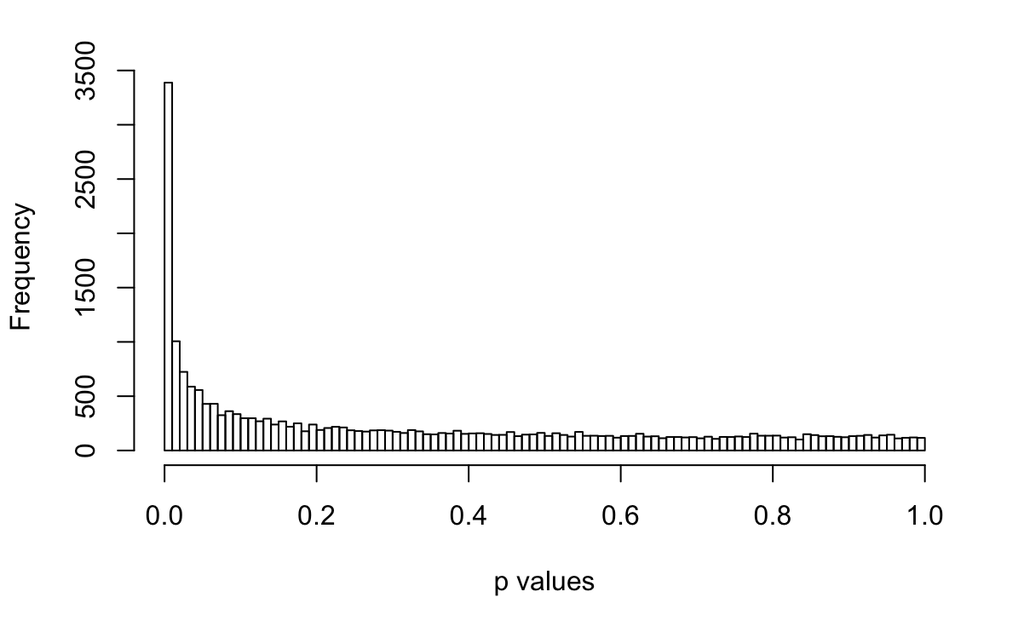

```r
hist(allStats$P.Value, breaks=100, xlab="p values", main="")
```

Let’s look at the volcano plot.

```r
par(mfrow=c(1,2))
## use the function available through limma:
volcanoplot(fitg, coef=2, highlight=1, names=fit$genes$ID,
            xlab="Log Fold Change", ylab="Log Odds", pch=16, cex=0.35)
## make your own volcano plot
plot(allStats$logFC, -log10(allStats$P.Value),
     cex=0.4, xlab="Log fold change", ylab="-log10(p value)")
```

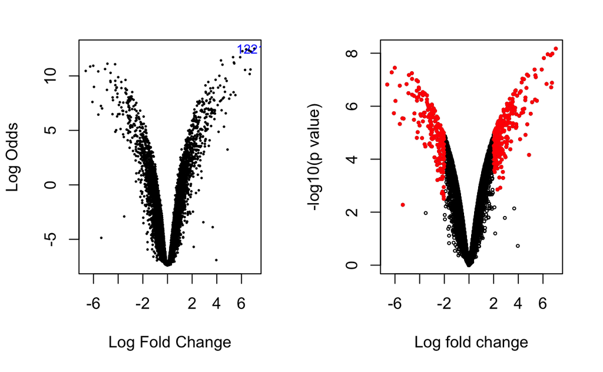

```r
points(allStats$logFC[allStats$adj.P.Val<0.05 & abs(allStats$logFC)>2],
       -log10(allStats$P.Value)[allStats$adj.P.Val<0.05 & abs(allStats$logFC)>2] ,
       col="red", cex=0.4, pch=19)
```

Now, we extract differentially expressed gene based on our criteria.

```r
DEGs_indx<- which(allStats$adj.P.Val<0.05 & abs(allStats$logFC)>2) ## 471 genes
DEGs<-dataGene[DEGs_indx,]       # it has expression values for DEGs
DEpvals<- allStats[DEGs_indx,]   # it gives p vals, logFC etc related to DEGs
DEGs$genes<- data.frame(DEGs$genes, DEpvals)
save(DEGs, file= "DEGs_stats_agilent.RData")
```